# Week 8: Regression

Andrew Smith and others

20/03/2022

```r
#install.packages("ggplot2")
##install.packages("performance")
#install.packages("dplyr")
#install.packages('see')
#install.packages('patchwork')
```

# A simple linear regression using the cars dataset

## Summary statistics

```r
summary(cars)
```

```
##      speed           dist
##  Min.   : 4.0   Min.   :  2.00
##  1st Qu.:12.0   1st Qu.: 26.00
##  Median :15.0   Median : 36.00
##  Mean   :15.4   Mean   : 42.98
##  3rd Qu.:19.0   3rd Qu.: 56.00
##  Max.   :25.0   Max.   :120.00
```

## Scatter plot

Plot stopping distance (dist) against speed.

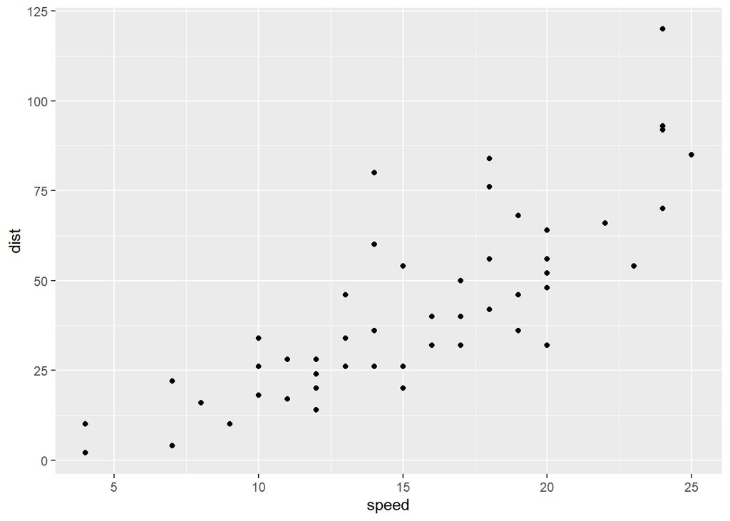

```r
library(ggplot2)
ggplot(cars, aes(x=speed, y=dist)) +
  geom_point() # + geom_smooth(method="lm")
```

```r
# What does adding geom_smooth do?
```

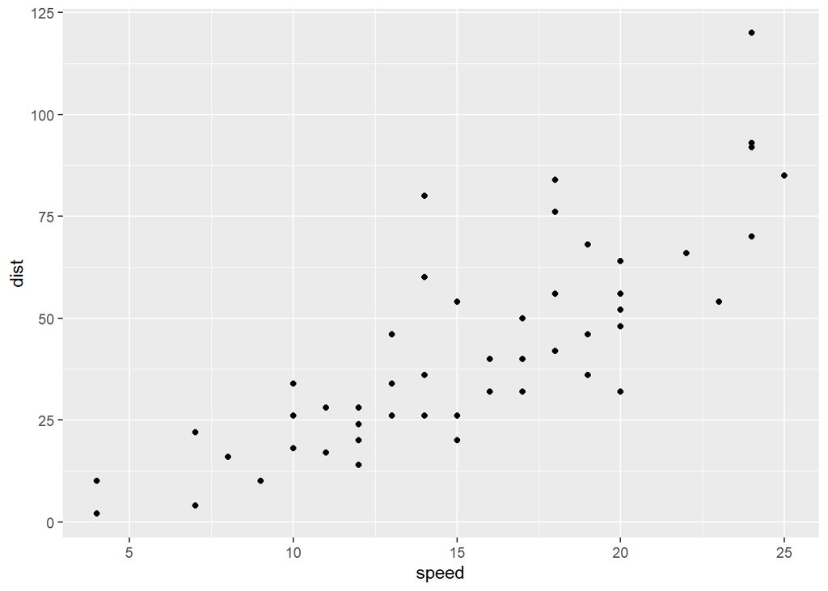

```r
library(ggplot2)
ggplot(cars, aes(x=speed, y=dist)) +
  geom_point() # + geom_smooth(method="lm")
```

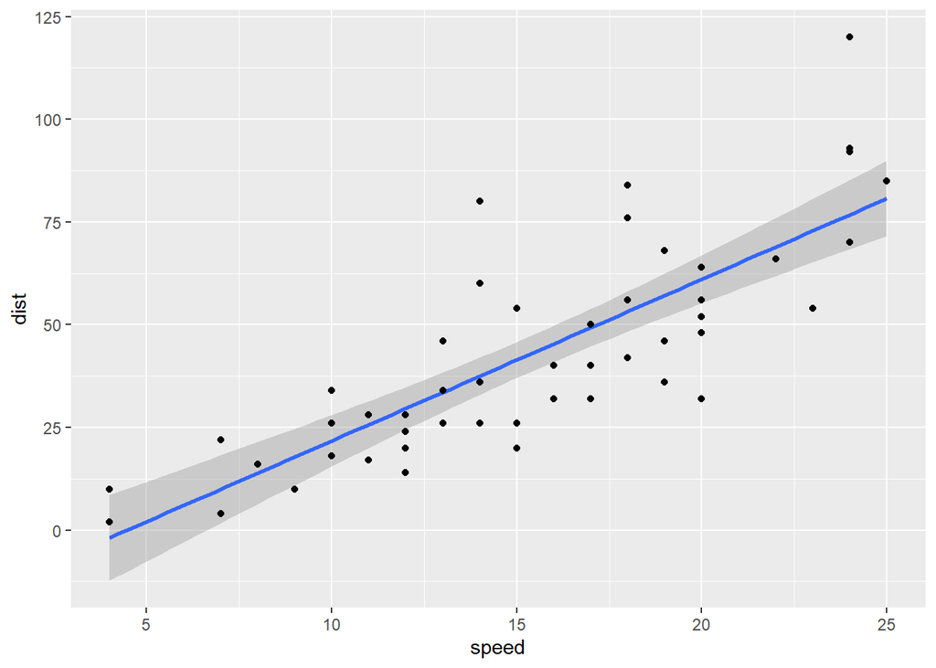

```r
library(ggplot2)
ggplot(cars, aes(x = speed, y= dist)) + geom_smooth(method = "lm") + geom_point()
```

What does this tell you?

Does this seem to be a good candidate for a simple linear regression?

## Correlation

Perform a linear correlation between these two variables. Is the linear correlation statistically significant?

```r
with(cars, cor(speed,dist))
```

```
## [1] 0.8068949
```

```r
with(cars, cor.test(speed,dist))
```

```
##
##  Pearson's product-moment correlation
##
## data:  speed and dist
## t = 9.464, df = 48, p-value = 1.49e-12
## alternative hypothesis: true correlation is not equal to 0
## 95 percent confidence interval:
##  0.6816422 0.8862036
## sample estimates:
##       cor
## 0.8068949
```

## Linear regression

Model the stopping distance of these cars (from the 1920s). You will need to identify your dependent variable.

```r
model1 <- lm(dist ~ speed, data=cars)
summary(model1)
```

```
##
## Call:
## lm(formula = dist ~ speed, data = cars)
##
## Residuals:
##     Min      1Q  Median      3Q     Max
## -29.069  -9.525  -2.272   9.215  43.201
##
## Coefficients:
##             Estimate Std. Error t value Pr(>|t|)
## (Intercept) -17.5791     6.7584  -2.601   0.0123 *
## speed         3.9324     0.4155   9.464 1.49e-12 ***
## ---
## Signif. codes:  0 '***' 0.001 '**' 0.01 '*' 0.05 '.' 0.1 ' ' 1
##
## Residual standard error: 15.38 on 48 degrees of freedom
## Multiple R-squared:  0.6511, Adjusted R-squared:  0.6438
## F-statistic: 89.57 on 1 and 48 DF,  p-value: 1.49e-12
```

Interpret the output of the model.

How would you explain the regression equation to someone?

$$\mbox{distance} = \beta_0 + \beta_1 \times \mbox{speed}$$

## Model fit

Assess the performance of the model.

Does it show evidence of breaking model assumptions?

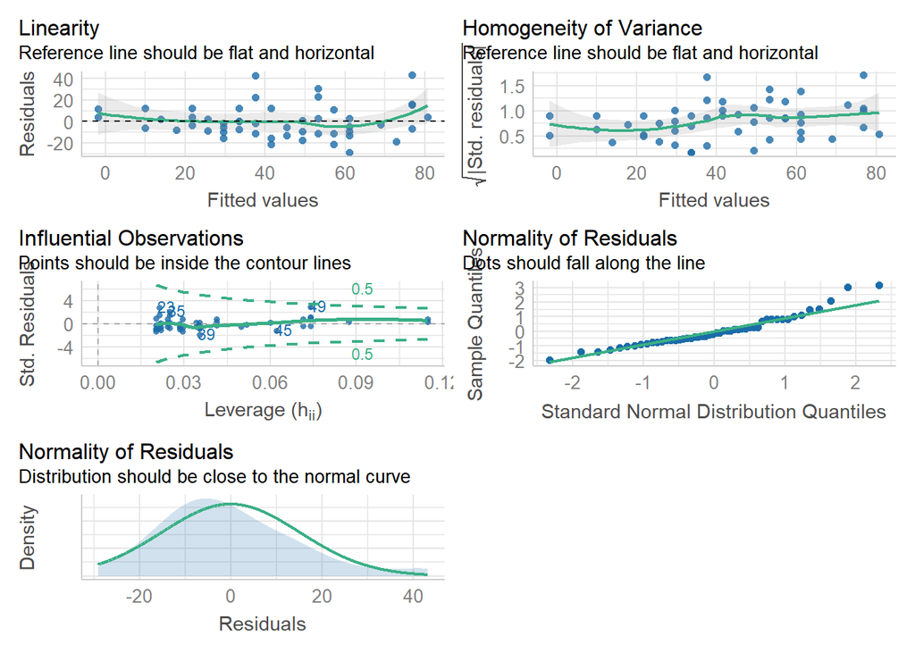

```r
library(performance)
check_model(model1)
```

# Dewis exercise ‘r regression’

Use the code chunk below to contain your code to answer the Dewis quesiton

```r
# Start your code here
```

# The mtcars dataset

```r
library(dplyr)
df <- mtcars %>%
select(-c(am, vs, cyl, gear, carb))
glimpse(df)
```

```
## Rows: 32
## Columns: 6
## $ mpg  <dbl> 21.0, 21.0, 22.8, 21.4, 18.7, 18.1, 14.3, 24.4, 22.8, 19.2, 17.8,~
## $ disp <dbl> 160.0, 160.0, 108.0, 258.0, 360.0, 225.0, 360.0, 146.7, 140.8, 16~
## $ hp   <dbl> 110, 110, 93, 110, 175, 105, 245, 62, 95, 123, 123, 180, 180, 180~
## $ drat <dbl> 3.90, 3.90, 3.85, 3.08, 3.15, 2.76, 3.21, 3.69, 3.92, 3.92, 3.92,~
## $ wt   <dbl> 2.620, 2.875, 2.320, 3.215, 3.440, 3.460, 3.570, 3.190, 3.150, 3.~
## $ qsec <dbl> 16.46, 17.02, 18.61, 19.44, 17.02, 20.22, 15.84, 20.00, 22.90, 18~
```

Pick which variable is the best single variable for explaining the variation in miles per gallon (mpg), using a simple linear regression model.

Fully document your process, including your exploratory data analysis, model evaluation and selection.

How would you explain your chosen model to someone without technical expertise?

```r
## Summary statistics

## Correlation
### Hint: choose the variable that has the biggest correlation with miles per gallon

## Scatter plot

## Linear regression

## Interpretation

## Model fit
```

R packages mentioned today that you may find useful include:

- corrplot (for visualisation of correlations across a set of variables) https://cran.r-project.org/web/packages/corrplot/vignettes/corrplot-intro.html
- performance (for model evaluation and comparison) https://easystats.github.io/see/articles/performance.html
- kableExtra (for tables) https://cran.r-project.org/web/packages/kableExtra/vignettes/awesome_table_in_html.html